# Box method for multiplying two two-digit numbers

Consider the product $52\cdot 43$.

- We will evaluate with the box method.
- First, break each factor into its tens and ones.
  $$52~=~ 50+2$$
  $$43~=~ 40+3$$
- We can make a 2x2 box, putting the first factor’s terms as column labels and the second factor’s terms as row labels.

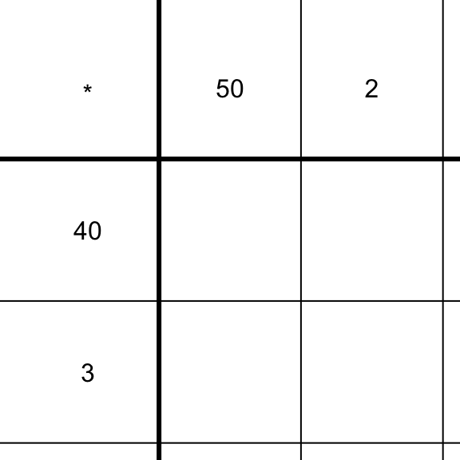

- Fill each cell with the product of its column label and its row label.

[figure not shown]

- Add up the results.
  $$2000+150+80+6$$
  $$2150+86$$
  $$2236$$

# Multiply two two-digit numbers with box method… Example 1

Use the box method to multiply.
$$73 \cdot
48$$

# Combining like terms

- “Terms” are expressions that are added (or subtracted) to something.
- “Factors” are expressions that are multiplied (or divided) by something.
- Terms can be composed of factors (and vice versa).
- We will start with 3 types of terms:
- Quadratic terms (a number times $x^2$)
- Linear terms (a number times $x$)
- Constant terms (just a number)
- A common step when simplifying expressions is to **combine like terms**. For example… imagine we are simplifying the following expression.
  $$4x+5+8x^2+7+9x-3x^2$$
- We identify the quadratic terms are $8x^2$ and $-3x^2$.
- We identify the linear terms are $4x$ and $9x$.
- We identify the constants are $5$ and $7$.
- Thus, when we combine like terms we get… (and put in standard order of quadratic, linear, and then constant)…
- We get
  $$5x^2+13x+12$$
- Notice “combine” means add the coefficients… and “coefficient” is the numerical part of the term.

# Combine-like-terms example 1

Consider the function below.

$$f(x)~=~ 6x^2 +8x+4+3x^2-x-2$$

When simplified, that function can be written in standard form:

$$f(x)~=~ ax^2+bx+c$$

where $a$, $b$, and $c$ are integers. Find $a$, $b$, and $c$.

- Combine the quadratic terms.
  $$6x^2+3x^2~\equiv~ 9x^2$$
- Combine the linear terms. Notice $-x$ is equivalent to $-1x$, but we do not write coefficients of 1 or -1.
  $$8x-x~\equiv~ 7x$$
- Combine the constant terms.
  $$4-2~\equiv~
  2$$
- Write the function.
  $$f(x)~=~
  9x^2+7x+2$$
- Identify the parameters.
  $$a=9$$
  $$b=7$$
  $$c=2$$

# Combine-like-terms example 2

Consider the function below.

$$f(x)~=~
2+8+4x-5x-3+9x^2-x-8x^2+6x$$

When simplified, that function can be written in standard form:

$$f(x)~=~ ax^2+bx+c$$

where $a$, $b$, and $c$ are integers. Find $a$, $b$, and $c$.

# Some simple examples of equivalent expressions

- Simplify $3x+4x$
- $7x$
- Simplify $x+4x$
- $5x$
- Simplify $3x^2+4x^2$
- $7x^2$
- Simplify $3x^2+4x$
- $3x^2+4x$ Notice we can only combine [like terms](https://en.wikipedia.org/wiki/Like_terms#Example).
- Simplify $(2)\cdot (x)$
- $2x$
- Simplify $(x)\cdot(x)$
- $x^2$
- Simplify $(3x)\cdot (5x)$
- $15x^2$
- Distribute $2\cdot (3x+5)$
- $6x+10$
- Distribute $x\cdot (3x+5)$
- $3x^2+5x$

# Distributing a sum times a sum

- What do I get when I distribute $(x+2)\cdot (3x+5)$?
- First, distribute $(x+2)$ to each term in $(3x+5)$.
  $$(x+2)\cdot 3x ~~~+~~~ (x+2)\cdot
  5$$
- Distribute $3x$ to each term in its $(x+2)$ multiplier.
  $$3x^2+6x ~~~+~~~ (x+2)\cdot 5$$
- Distribute $5$ to each term in its $(x+2)$ multiplier.
  $$3x^2+6x ~~~+~~~ 5x+10$$
- Notice we have two [like terms](https://en.wikipedia.org/wiki/Like_terms#Example).
- Combine the like terms.
- You get:
  $$3x^2+11x+10$$
- When we get rid of parentheses and combine like terms, we call the process “expansion”. You can be asked to “expand the expression”.

# Multiply linear binomials with box method

Expand the expression shown below.

$$(2x+3)\cdot (4x+5)$$

- We can make a 2x2 box, putting the first factor’s terms as row labels and the second factor’s terms as column labels.

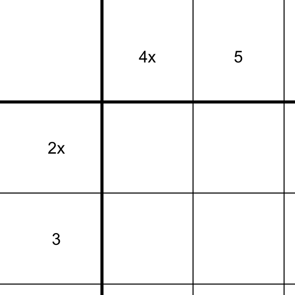

- In each cell, write the product of the column label and row label

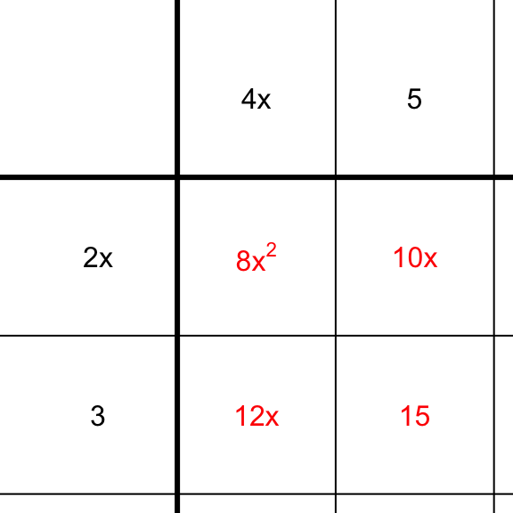

- Write the terms.
  $$8x^2+10x+12x+15$$
- Combine the two linear terms to get the answer:
  $$8x^2+22x+15$$
- Notice, this is the same result we would get by following the method on the previous slide of repeatedly distributing.